# assignment_2.1

Charles Hendrickson

10/10/2021

Assignment 2.1 – dataRetrieval 1) Add the Santa Paula Creek gauge to exercise we did in class 2) What is the best way to query multiple sites using this R package? 3) Create a plot showing any stream flow response to the rain of last night (10/04). Determine at what time did the stream flow peaked (if any) at the two locations?

What we did in class (for reference):

```r
library(dataRetrieval)
library(tidyverse)
library(kableExtra)
```

# Exercise 1

# Start a new Markdown document to plot the discharge time-series for the Ventura River from 2019-10-01 to 2020-10-05

```r
# Ventura River discharge time-series:
siteNumber <- "11118500"
parameterCd <- "00060"  # Discharge
startDate <- "2019-10-01"
endDate <- "2020-10-05"

discharge <- readNWISdv(siteNumber,
                    parameterCd, startDate, endDate)
```

```r
discharge <- discharge %>%
  rename(discharge = X_00060_00003)
```

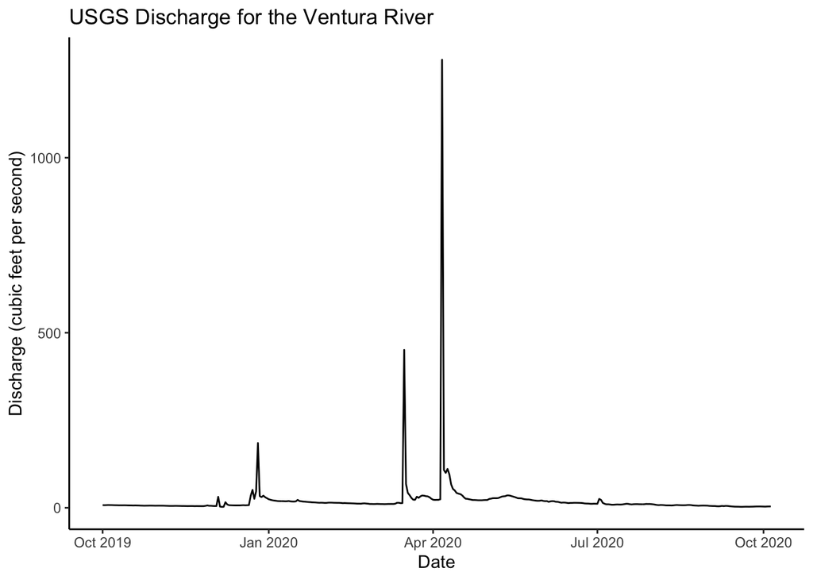

```r
ggplot(data = discharge, aes(x = Date, y = discharge)) +
  geom_line() +
  labs(title = "USGS Discharge for the Ventura River",
       x = "Date",
       y = "Discharge (cubic feet per second)") +
  theme_classic()
```

# Now add the Santa Paula Creek gauge to exercise we did in class:

# Question: What is the best way to query multiple sites using this R package?

# Answer: I think the best way to query multiple sites using this R package is to combine both sites into a vector, which puts both sites into the same data frame.

Santa Paula Creek and Ventura River discharge time-series for October 4-5th:

```r
# Santa Paula Creek discharge time-series:
SP_and_V_discharge <- readNWISdata(sites= c("11113500","11118500"), service="iv",
                   parameterCd="00060",
                   startDate="2021-10-04T00:00Z", endDate="2021-10-05T11:59Z",
                   tz = "America/Los_Angeles")
```

```r
# Rename the column `X_00060_00000` as `discharge`
SP_and_V_discharge <- SP_and_V_discharge %>%
  rename(discharge = X_00060_00000)
```

# Create a plot showing any stream flow response to the rain of last night (10/04). Determine at what time did the stream flow peaked (if any) at the two locations?

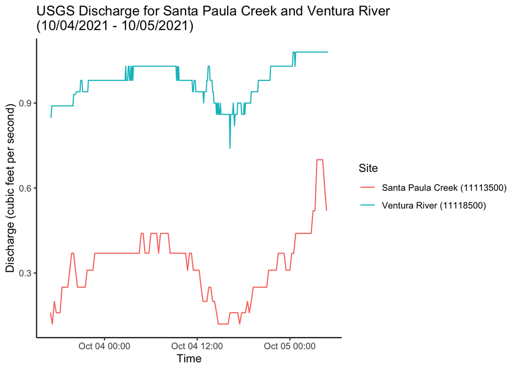

```r
library(ggplot2)

ggplot(data = SP_and_V_discharge, aes(x = dateTime, y = discharge)) +
  geom_line(aes(color = site_no)) +
  labs(title = "USGS Discharge for Santa Paula Creek and Ventura River
(10/04/2021 - 10/05/2021)",
       x = "Time",
       y = "Discharge (cubic feet per second)") +
  scale_color_discrete(name = "Site", labels = c("Santa Paula Creek (11113500)", "Ventura River (11118500)")) +
  theme_classic()
```

Determine at what time did the stream flow peaked (if any) at the two locations?

```r
# Create separate data frames for the two sites
santa_paula_creek <- SP_and_V_discharge %>%
  filter(site_no == 11113500)

ventura_river <- SP_and_V_discharge %>%
  filter(site_no == 11118500)
```

```r
# Find what the max discharge was for the two sites
max_flow_santa_paula_creek <- max(santa_paula_creek$discharge)
max_flow_santa_paula_creek
```

```
## [1] 0.7
```

```r
max_flow_ventura_river <- max(ventura_river$discharge)
max_flow_ventura_river
```

```
## [1] 1.08
```

```r
# Filter for the time when the max discharge occurred
time_max_flow_santa_paula <- santa_paula_creek %>%
  filter(discharge == max_flow_santa_paula_creek) %>%
  select(dateTime, discharge)

kable(time_max_flow_santa_paula)
```

| dateTime | discharge |
| --- | --- |
| 2021-10-05 03:30:00 | 0.7 |
| 2021-10-05 03:45:00 | 0.7 |
| 2021-10-05 04:00:00 | 0.7 |
| 2021-10-05 04:15:00 | 0.7 |

```r
time_max_flow_ventura <- ventura_river %>%
  filter(discharge == max_flow_ventura_river) %>%
  select(dateTime, discharge)

kable(time_max_flow_ventura)
```

| dateTime | discharge |
| --- | --- |
| 2021-10-05 00:25:00 | 1.08 |
| 2021-10-05 00:30:00 | 1.08 |
| 2021-10-05 00:35:00 | 1.08 |
| 2021-10-05 00:45:00 | 1.08 |
| 2021-10-05 00:50:00 | 1.08 |
| 2021-10-05 00:55:00 | 1.08 |
| 2021-10-05 01:00:00 | 1.08 |
| 2021-10-05 01:05:00 | 1.08 |
| 2021-10-05 01:10:00 | 1.08 |
| 2021-10-05 01:15:00 | 1.08 |
| 2021-10-05 01:20:00 | 1.08 |
| 2021-10-05 01:25:00 | 1.08 |
| 2021-10-05 01:30:00 | 1.08 |
| 2021-10-05 01:35:00 | 1.08 |
| 2021-10-05 01:40:00 | 1.08 |
| 2021-10-05 01:45:00 | 1.08 |
| 2021-10-05 01:50:00 | 1.08 |
| 2021-10-05 01:55:00 | 1.08 |
| 2021-10-05 02:00:00 | 1.08 |
| 2021-10-05 02:05:00 | 1.08 |
| 2021-10-05 02:10:00 | 1.08 |
| 2021-10-05 02:15:00 | 1.08 |
| 2021-10-05 02:20:00 | 1.08 |
| 2021-10-05 02:25:00 | 1.08 |
| 2021-10-05 02:30:00 | 1.08 |
| 2021-10-05 02:35:00 | 1.08 |
| 2021-10-05 02:40:00 | 1.08 |
| 2021-10-05 02:45:00 | 1.08 |
| 2021-10-05 02:50:00 | 1.08 |
| 2021-10-05 02:55:00 | 1.08 |
| 2021-10-05 03:00:00 | 1.08 |
| 2021-10-05 03:05:00 | 1.08 |
| 2021-10-05 03:10:00 | 1.08 |
| 2021-10-05 03:15:00 | 1.08 |
| 2021-10-05 03:20:00 | 1.08 |
| 2021-10-05 03:25:00 | 1.08 |
| 2021-10-05 03:30:00 | 1.08 |
| 2021-10-05 03:35:00 | 1.08 |
| 2021-10-05 03:40:00 | 1.08 |
| 2021-10-05 03:45:00 | 1.08 |
| 2021-10-05 03:50:00 | 1.08 |
| 2021-10-05 03:55:00 | 1.08 |
| 2021-10-05 04:00:00 | 1.08 |
| 2021-10-05 04:05:00 | 1.08 |
| 2021-10-05 04:10:00 | 1.08 |
| 2021-10-05 04:15:00 | 1.08 |
| 2021-10-05 04:20:00 | 1.08 |
| 2021-10-05 04:25:00 | 1.08 |
| 2021-10-05 04:30:00 | 1.08 |
| 2021-10-05 04:35:00 | 1.08 |
| 2021-10-05 04:40:00 | 1.08 |
| 2021-10-05 04:45:00 | 1.08 |
| 2021-10-05 04:50:00 | 1.08 |
| 2021-10-05 04:55:00 | 1.08 |